# Adversarial Search: Playing Connect 4

Student Name: [Zahra Hoobakht]

I understand that my submission needs to be my own work: [ZH]

## Instructions

Total Points: Undegraduates 100, graduate students 110

Complete this notebook and submit it. The notebook needs to be a complete project report with your implementation, documentation including a short discussion of how your implementation works and your design choices, and experimental results (e.g., tables and charts with simulation results) with a short discussion of what they mean. Use the provided notebook cells and insert additional code and markdown cells as needed.

## Introduction

You will implement different versions of agents that play Connect 4:

> "Connect 4 is a two-player connection board game, in which the players choose a color and then take turns dropping colored discs into a seven-column, six-row vertically suspended grid. The pieces fall straight down, occupying the lowest available space within the column. The objective of the game is to be the first to form a horizontal, vertical, or diagonal line of four of one's own discs." (see [Connect Four on Wikipedia](https://en.wikipedia.org/wiki/Connect_Four))

Note that [Connect-4 has been solved](https://en.wikipedia.org/wiki/Connect_Four#Mathematical_solution) in 1988. A connect-4 solver with a discussion of how to solve different parts of the problem can be found here: https://connect4.gamesolver.org/en/

## Task 1: Defining the Search Problem [10 point]

Define the components of the search problem:

- Initial state
- Actions
- Transition model (result function)
- Goal state (terminal state and utility)

Describe each component and then implement it as a function that can be used by search algorithms.

The initial state of Connect 4 is an empty game board. It consists of a grid with 7 columns and 6 rows, where no discs have been placed yet. We can represent this state using a two-dimensional array, where each cell is empty.

The actions in Connect 4 are the valid moves a player can make during their turn. Specifically, a player can drop a disc into any of the 7 columns as long as that column is not full (i.e., it has fewer than 6 discs).

The transition model defines the outcome of taking a particular action from a given state. When a player drops a disc into a column, the model updates the game board by placing the disc in the lowest available position in that column.

The goal state occurs when a player successfully connects four of their discs in a row (horizontally, vertically, or diagonally). If a player wins, the utility can be 1 for the winning player, -1 for the losing player and 0 for the draw.

How big is the state space? Give an estimate and explain it.

we have 42 cells and each cell in the grid can have three possible values of 1 (the player 1's disc), 2 (the player 2's disc) and 0 (empty spot). Therefore the state space is 3^42

How big is the game tree that minimax search will go through? Give an estimate and explain it.

To estimate the size of the game tree that a minimax search will go through in Connect 4, we need to consider the depth of the search, the branching factor, and the nature of the game itself.The depth of the search corresponds to how many turns into the game the minimax algorithm will explore. In Connect 4, the game can go on for a maximum of 42 moves (when the board is completely filled). The branching factor (number of moves possible at each turn) is 7, as there are 7 columns where pieces can be dropped.The total number of nodes in a game tree 7^42

## Task 2: Game Environment and Random Agent [25 point]

Use a numpy character array as the board.

```python
import numpy as np

def empty_board(shape=(6, 7)):
    return np.full(shape=shape, fill_value=0)

print(empty_board())
```

```
[[0 0 0 0 0 0 0]
 [0 0 0 0 0 0 0]
 [0 0 0 0 0 0 0]
 [0 0 0 0 0 0 0]
 [0 0 0 0 0 0 0]
 [0 0 0 0 0 0 0]]
```

The standard board is $6 \times 7$ but you can use smaller boards to test your code. Instead of colors (red and yellow), I use 1 and -1 to represent the players. Make sure that your agent functions all have the from: `agent_type(board, player = 1)`, where board is the current board position (in the format above) and player is the player whose next move it is and who the agent should play (as 1 and -1).

[figure not shown]

```python
# Visualization code by Randolph Rankin

import matplotlib.pyplot as plt

def visualize(board):
    plt.axes()
    rectangle=plt.Rectangle((-0.5,len(board)*-1+0.5),len(board[0]),len(board),fc='blue')
    circles=[]
    for i,row in enumerate(board):
        for j,val in enumerate(row):
            color='white' if val==0 else 'red' if val==1 else 'yellow'
            circles.append(plt.Circle((j,i*-1),0.4,fc=color))

    plt.gca().add_patch(rectangle)
    for circle in circles:
        plt.gca().add_patch(circle)

    plt.axis('scaled')
    plt.show()

board = [[0, 0, 0, 0, 0, 0, 0],
         [0, 0, 0, 0, 0, 0, 0],
         [0, 0, 0, 0, 0, 0, 0],
         [0, 0, 0, 1, 0, 0, 0],
         [0, 0, 0, 1, 0, 0, 0],
         [0,-1,-1, 1,-1, 0, 0]]
visualize(board)
```

Implement helper functions for:

- A check for available actions in each state `actions(state)`.
- The transition model `result(state, player, action)`.
- Check for terminal states `terminal(state)`.
- The utility function `utility(s, player)`.

Some functions have the player in there so your agent will be able to play red or yellow. Make sure that all these functions work with boards of different sizes (number of columns and rows).

```python
#Returns a list of available actions (columns) where a piece can be dropped.
def actions(state):
    available_actions = []
    state = np.array(state)
    num_rows, num_cols = state.shape
    for col in range(num_cols):
        if state[0, col] == 0: # Check if the topmost row of the column is empty
            available_actions.append(col)
    return available_actions

actions(board) # returns a list of columns that a disc can be dropped
```

```
[0, 1, 2, 3, 4, 5, 6]
```

```python
#Returns a new board state after the player drops a piece in the specified column.
def result(state, player, action):

    state = np.array(state)
    if player==1:

        for row in range(state.shape[0]):
            if state[-1-row,action]==0:
                state[-1-row, action] =1
                break
            else:
                continue
    elif player==-1:

        for row in range(state.shape[0]):
            if state[-1-row,action]==0:
                state[-1-row, action] =-1
                break
            else:
                continue
    return state
```

```python
def terminal(state):
    state = np.array(state)
    num_rows, num_cols = state.shape

    Flag=0
    for j in range(num_cols):
        for a in range(num_rows):
            #print('a',a)
            if a>=num_rows%4+1 :#3
                continue
            elif state[num_rows-1-a,j]+state[num_rows-1-a-1,j]+state[num_rows-1-a-2,j]+state[num_rows-1-a-3,j]==4 or state[num_rows-1-a,j]+state[num_rows-1-a-1,j]+state[num_rows-1-a-2,j]+state[num_rows-1-a-3,j]==-4:
                Flag='Win'



    for j in range(num_cols):
        for a in range(num_rows):
            #print('a',a)
            if j>=num_cols%4+1:#4
                continue

            elif state[num_rows-1-a,j]+state[num_rows-1-a,j+1]+state[num_rows-1-a,j+2]+state[num_rows-1-a,j+3]==4 or state[num_rows-1-a,j]+state[num_rows-1-a,j+1]+state[num_rows-1-a,j+2]+state[num_rows-1-a,j+3]==-4:

                Flag='Win'


    for j in range(num_cols):
        for a in range(num_rows):
            #print('a',a)
            if a>=num_rows%4+1 or j>=num_cols%4+1:#4
                continue

            elif state[num_rows-1-a,j]+state[num_rows-1-a-1,j+1]+state[num_rows-1-a-2,j+2]+state[num_rows-1-a-3,j+3]==4 or state[num_rows-1-a,j]+state[num_rows-1-a-1,j+1]+state[num_rows-1-a-2,j+2]+state[num_rows-1-a-3,j+3]==-4:
                Flag='Win'

            elif state[num_rows-1-a,-1-j]+state[num_rows-1-a-1,-2-j]+state[num_rows-1-a-2,-3-j]+state[num_rows-1-a-3,-4-j]==4 or state[num_rows-1-a,-1-j]+state[num_rows-1-a-1,-2-j]+state[num_rows-1-a-2,-3-j]+state[num_rows-1-a-3,-4-j]==-4:
                Flag='Win'


    if actions(state)==[] and Flag!='Win':
        Flag='Draw'

    return Flag
```

```python
def utility(state, player):
    state = np.array(state)
    num_rows, num_cols = state.shape
    Flag=None # If no winner, utility is 0
    for j in range(num_cols):
        for a in range(num_rows):
            if a>=num_rows%4+1 :#3
                continue
            elif state[num_rows-1-a,j]+state[num_rows-1-a-1,j]+state[num_rows-1-a-2,j]+state[num_rows-1-a-3,j]==4 :

                Flag= 4
            elif state[num_rows-1-a,j]+state[num_rows-1-a-1,j]+state[num_rows-1-a-2,j]+state[num_rows-1-a-3,j]==-4:
                Flag= -4
    for j in range(num_cols):
        for a in range(num_rows):
            if j>=num_cols%4+1:#4
                continue

            elif state[num_rows-1-a,j]+state[num_rows-1-a,j+1]+state[num_rows-1-a,j+2]+state[num_rows-1-a,j+3]==4 :
                Flag= 4

            elif state[num_rows-1-a,j]+state[num_rows-1-a,j+1]+state[num_rows-1-a,j+2]+state[num_rows-1-a,j+3]==-4:

                Flag= -4

    for j in range(num_cols):
            for a in range(num_rows):
                #print('a',a)
                if a>=num_rows%4+1 or j>=num_cols%4+1:
                    continue

                elif state[num_rows-1-a,j]+state[num_rows-1-a-1,j+1]+state[num_rows-1-a-2,j+2]+state[num_rows-1-a-3,j+3]==-4 or state[num_rows-1-a,-1-j]+state[num_rows-1-a-1,-2-j]+state[num_rows-1-a-2,-3-j]+state[num_rows-1-a-3,-4-j]==-4:
                    Flag=-4


                elif  state[num_rows-1-a,j]+state[num_rows-1-a-1,j+1]+state[num_rows-1-a-2,j+2]+state[num_rows-1-a-3,j+3]==4 or state[num_rows-1-a,-1-j]+state[num_rows-1-a-1,-2-j]+state[num_rows-1-a-2,-3-j]+state[num_rows-1-a-3,-4-j]==4:
                    Flag= 4

    return Flag
```

Implement an agent that plays randomly. Make sure the agent function receives as the percept the board and returns a valid action. Use an agent function definition with the following signature (arguments):

`def random_player(board, player = 1): ...`

The argument `player` is used for agents that do not store what color they are playing. The value passed on by the environment should be 1 ot -1 for player red and yellow, respectively. See [Experiments section for tic-tac-toe](https://nbviewer.org/github/mhahsler/CS7320-AI/blob/master/Games/tictactoe_and_or_tree_search.ipynb#Experiments) for an example.

```python
def random_player(board, player=1):
    valid_moves=actions(board)
    return np.random.choice(valid_moves)
```

Let two random agents play against each other 1000 times. Look at the [Experiments section for tic-tac-toe](https://nbviewer.org/github/mhahsler/CS7320-AI/blob/master/Games/tictactoe_and_or_tree_search.ipynb#Experiments) to see how the environment uses the agent functions to play against each other.

How often does each player win? Is the result expected?

```python
def Game(board,player):
    current_player =player

    while not( terminal(board)=='Win') and not ( terminal(board)=='Draw'):

        valid_moves=random_player(board, current_player)
        board=result(board, current_player, valid_moves)
        #print( terminal(board),current_player,valid_moves)
        current_player *= -1

#     if utility(board, current_player)==4:
#         print('red won')
#     elif utility(board, current_player)==-4:
#         print('yellow won')
#     else:
#         print('Draw')
    #print(utility(board, current_player))
    #visualize(board)
    return board,utility(board, current_player)
```

[figure not shown]

```
-4
```

```python
board3,util=Game(empty_board(),1)
visualize(board3)
print(utility(board3,player=1))
```

```python
utility_number=[]
for i in range(0,1000):
    board3,util=Game(empty_board(),np.random.choice([1,-1]))
    utility_number.append(util)
```

```python
count_4 = utility_number.count(4)
count_minus_4 = utility_number.count(-4)
count_0 = utility_number.count(0)
```

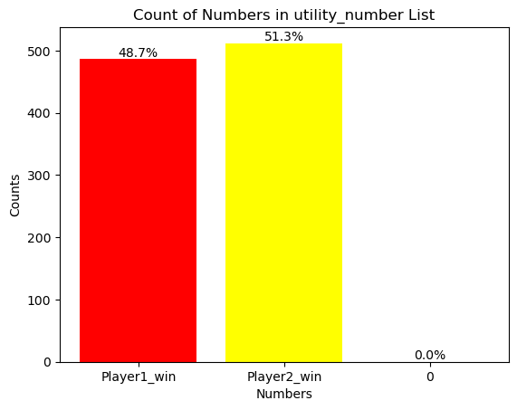

```python
labels = ['Player1_win', 'Player2_win', '0']
counts = [count_4, count_minus_4, count_0]
import matplotlib.pyplot as plt

plt.bar(labels, counts, color=[ 'red','yellow', 'green'])
plt.xlabel('Numbers')
plt.ylabel('Counts')
plt.title('Count of Numbers in utility_number List')
total_count = count_4 + count_minus_4 + count_0
percentage_4 = (count_4 / total_count) * 100
percentage_minus_4 = (count_minus_4 / total_count) * 100
percentage_0 = (count_0 / total_count) * 100
percentages = [percentage_4, percentage_minus_4, percentage_0]
for i, count in enumerate(counts):
    plt.text(i, count, f'{percentages[i]:.1f}%', ha='center', va='bottom')
plt.show()
```

I expected that the winning percentages are near to 50% because of randomness and they are.

## Task 3: Minimax Search with Alpha-Beta Pruning

### Implement the Search [20 points]

Implement minimax search starting from a given board for specifying the player.

**Important Notes:**

- You can use code from the [tic-tac-toe example](https://nbviewer.org/github/mhahsler/CS7320-AI/blob/master/Games/tictactoe_alpha_beta_tree_search.ipynb).
- Make sure that all your agent functions have a signature consistent with the random agent above and that it [uses a class to store state information.](https://nbviewer.org/github/mhahsler/CS7320-AI/blob/master/HOWTOs/store_agent_state_information.ipynb) This is essential to be able play against agents from other students later.
- The game tree for a $6 \times 7$ board is huge and optimal algorithms need to visit each or a large percentage of all nodes in the tree. You can experiment with smaller boards like a $4 \times 4$ board first.

```
Time taken: 0.0073451995849609375 seconds
Best Move: 2
Value of the State: 1
Nodes Visited: 104
```

[figure not shown]

```python
import numpy as np
import matplotlib.pyplot as plt

# Minimax Agent with Alpha-Beta Pruning
class MinimaxAgent:
    def __init__(self):
        self.count = 0  # Track the number of nodes visited

    def minimax(self, state, player=1):
        """
        Perform the minimax search with alpha-beta pruning.
        """
        self.count = 0
        value, move = self.max_value(state, player, float('-inf'), float('inf')) if player == 1 else self.min_value(state, player, float('-inf'), float('inf'))
        return value, move

    def max_value(self, state, player, alpha, beta):
        """
        Maximizing player's move.
        """
        self.count += 1
        v = self.utility(state, player)
        if v is not None:
            return v, None

        v, move = float('-inf'), None
        for a in self.actions(state):
            v2, _ = self.min_value(self.result(state, player, a), -player, alpha, beta)
            if v2 > v:
                v, move = v2, a
            alpha = max(alpha, v)
            if v >= beta:  # Prune remaining branches
                break
        return v, move

    def min_value(self, state, player, alpha, beta):
        """
        Minimizing player's move.
        """
        self.count += 1
        v = self.utility(state, player)
        if v is not None:
            return v, None

        v, move = float('inf'), None
        for a in self.actions(state):
            v2, _ = self.max_value(self.result(state, player, a), -player, alpha, beta)
            if v2 < v:
                v, move = v2, a
            beta = min(beta, v)
            if v <= alpha:  # Prune remaining branches
                break
        return v, move

    def utility(self, state, player):
        """
        Check for a winning condition and return the utility value.
        """
        num_rows, num_cols = np.array(state).shape
        for j in range(num_cols):
            for a in range(num_rows - 3):
                if sum(state[num_rows - 1 - a - k][j] for k in range(4)) == 4:
                    return 1
                elif sum(state[num_rows - 1 - a - k][j] for k in range(4)) == -4:
                    return -1
        for a in range(num_rows):
            for j in range(num_cols - 3):
                if sum(state[num_rows - 1 - a][j + k] for k in range(4)) == 4:
                    return 1
                elif sum(state[num_rows - 1 - a][j + k] for k in range(4)) == -4:
                    return -1
        # Diagonal checks
        for a in range(num_rows - 3):
            for j in range(num_cols - 3):
                if sum(state[num_rows - 1 - a - k][j + k] for k in range(4)) == 4:
                    return 1
                elif sum(state[num_rows - 1 - a - k][j + k] for k in range(4)) == -4:
                    return -1
        return 0 if all(state[0][col] != 0 for col in range(num_cols)) else None

    def actions(self, state):
        """
        Return a list of valid moves (columns).
        """
        return [col for col in range(len(state[0])) if state[0][col] == 0]

    def result(self, state, player, action):
        """
        Return the resulting state after applying the action.
        """
        new_state = [row[:] for row in state]  # Deep copy
        for row in range(len(new_state) - 1, -1, -1):
            if new_state[row][action] == 0:
                new_state[row][action] = player
                break
        return new_state

# Initial board setup
board1 = [
    [0, 0, 0, 0],
    [0, 0, 1, 0],
    [-1, 0, 1, 0],
    [-1, -1, 1, -1]
]

# Run Minimax with Alpha-Beta Pruning and visualize the result
import time


start_time = time.time()
agent = MinimaxAgent()
value, best_move = agent.minimax(board1, player=1)
end_time = time.time()

print(f"Time taken: {end_time - start_time} seconds")
print("Best Move:", best_move)
print("Value of the State:", value)
print("Nodes Visited:", agent.count)

# Update the board with the best move
final_board = agent.result(board1, 1, best_move)

# Visualize the final board


visualize(final_board)
```

Experiment with some manually created boards (at least 5) to check if the agent spots winning opportunities.

```
Time taken: 0.0039882659912109375 seconds
Best Move: 2
Value of the State: 1
Nodes Visited: 58
```

[figure not shown]

```python
# Initial board setup
board1 = [
    [0, 0, 0, 0],
    [1, 0, 1, -1],
    [-1, 1, 1, 1],
    [-1, -1, 1, -1]
]

# Run Minimax with Alpha-Beta Pruning and visualize the result


start_time = time.time()
agent = MinimaxAgent()
value, best_move = agent.minimax(board1, player=1)
end_time = time.time()

print(f"Time taken: {end_time - start_time} seconds")
print("Best Move:", best_move)
print("Value of the State:", value)
print("Nodes Visited:", agent.count)

# Update the board with the best move
final_board = agent.result(board1, -1, best_move)

# Visualize the final board


visualize(final_board)
```

```
Time taken: 0.0029909610748291016 seconds
Best Move: 0
Value of the State: 1
Nodes Visited: 34
```

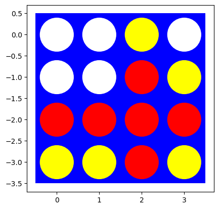

```python
# Initial board setup
board1 = [
    [0, 0, -1, 0],
    [0, 0, 1, -1],
    [0, 1, 1, 1],
    [-1, -1, 1, -1]
]

# Run Minimax with Alpha-Beta Pruning and visualize the result
start_time = time.time()
agent = MinimaxAgent()
value, best_move = agent.minimax(board1, player=1)
end_time = time.time()

print(f"Time taken: {end_time - start_time} seconds")
print("Best Move:", best_move)
print("Value of the State:", value)
print("Nodes Visited:", agent.count)

# Update the board with the best move
final_board = agent.result(board1, 1, best_move)

# Visualize the final board


visualize(final_board)
```

```
Time taken: 0.001994609832763672 seconds
Best Move: 0
Value of the State: 1
Nodes Visited: 34
```

[figure not shown]

```python
# Initial board setup
board1 = [
    [0, 0, -1, 0],
    [0, 0, 1, -1],
    [0, 1, 1, 1],
    [-1, -1, 1, -1]
]

# Run Minimax with Alpha-Beta Pruning and visualize the result
start_time = time.time()
agent = MinimaxAgent()
value, best_move = agent.minimax(board1, player=1)
end_time = time.time()

print(f"Time taken: {end_time - start_time} seconds")
print("Best Move:", best_move)
print("Value of the State:", value)
print("Nodes Visited:", agent.count)

# Update the board with the best move
final_board = agent.result(board1, -1, best_move)

# Visualize the final board


visualize(final_board)
```

```
Time taken: 0.0029888153076171875 seconds
Best Move: 3
Value of the State: 1
Nodes Visited: 66
```

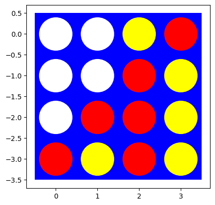

```python
# Initial board setup
board1 = [
    [0, 0, -1, 0],
    [0, 0, 1, -1],
    [0, 1, 1, -1],
    [1, -1, 1, -1]
]

# Run Minimax with Alpha-Beta Pruning and visualize the result
start_time = time.time()
agent = MinimaxAgent()
value, best_move = agent.minimax(board1, player=1)
end_time = time.time()

print(f"Time taken: {end_time - start_time} seconds")
print("Best Move:", best_move)
print("Value of the State:", value)
print("Nodes Visited:", agent.count)

# Update the board with the best move
final_board = agent.result(board1, 1, best_move)

# Visualize the final board


visualize(final_board)
```

```
Time taken: 0.004985809326171875 seconds
Best Move: 3
Value of the State: 1
Nodes Visited: 66
```

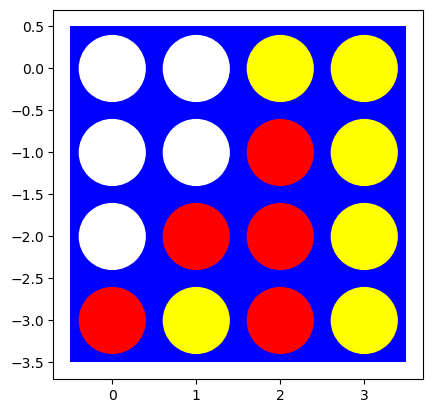

```python
# Initial board setup
board1 = [
    [0, 0, -1, 0],
    [0, 0, 1, -1],
    [0, 1, 1, -1],
    [1, -1, 1, -1]
]

# Run Minimax with Alpha-Beta Pruning and visualize the result
start_time = time.time()
agent = MinimaxAgent()
value, best_move = agent.minimax(board1, player=1)
end_time = time.time()

print(f"Time taken: {end_time - start_time} seconds")
print("Best Move:", best_move)
print("Value of the State:", value)
print("Nodes Visited:", agent.count)

# Update the board with the best move
final_board = agent.result(board1, -1, best_move)

# Visualize the final board


visualize(final_board)
```

How long does it take to make a move? Start with a smaller board with 4 columns and make the board larger by adding columns/rows. Explain why using this algorithm on a standard $6 \times 7$ board takes forever.

In 4x4 board we have Branching factor (b)of at most 4 actions per turn and Maximum depth (d) up to 16 moves (full board). Time complexity is calculated as 4^16=4,294,967,296 nodes in the worst case. Even with alpha-beta pruning reducing the number of nodes evaluated, this is still computationally expensive. for 6x7 board the total nodes will change to 7^42

### Move ordering [5 points]

Starting the search with better moves will increase the efficiency of alpha-beta pruning. Describe and implement a simple move ordering strategy. Make a table that shows how the ordering strategies influence the time it takes to make a move?

Evaluate the most promising moves first. For instance we van prioritize moves that lead to immediate wins or block opponent's wins. Prioritize central columns in games like Connect 4 because they are typically more strategic. With better move ordering, alpha-beta pruning becomes more effective, cutting down the number of branches evaluated.

```
Number of nodes searched: 257
Agent chose column: 2, with value: 1
Updated board:
```

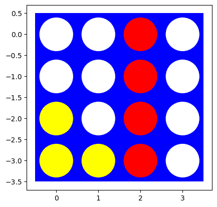

```python
import math
import numpy as np

class Connect4Agent:
    def __init__(self):
        self.DEBUG = 1  # For debugging purposes
        self.COUNT = 0

    def alpha_beta_search(self, board, player=1):
        """Start the search."""
        self.COUNT = 0
        value, move = self.max_value_ab(board, player, -math.inf, +math.inf)

        if self.DEBUG >= 1:
            print(f"Number of nodes searched: {self.COUNT}")

        return {"move": move, "value": value}

    def max_value_ab(self, state, player, alpha, beta):
        """Player's best move."""
        self.COUNT += 1
        v = self.utility(state, player)
        if self.DEBUG >= 2:
            print(f"max: {state} [alpha,beta]=[{alpha},{beta}] v={v}")
        if v is not None:
            if self.DEBUG >= 2:
                print(f" found terminal state. backtracking.")
            return v, None

        v, move = -math.inf, None

        for a in self.actions(state):
            v2, _ = self.min_value_ab(self.result(state, player, a), player, alpha, beta)
            if self.DEBUG >= 2:
                print(f"max: {state} (backtracked) [alpha,beta]=[{alpha},{beta}] v={v2}")

            if v2 > v:
                v, move = v2, a
            alpha = max(alpha, v)
            if v >= beta:
                if self.DEBUG >= 2:
                    print(f" v >= beta ({v} >= {beta}): pruning remaining subtree.")
                return v, move

        return v, move

    def min_value_ab(self, state, player, alpha, beta):
        """Opponent's best response."""
        self.COUNT += 1
        v = self.utility(state, player)
        if self.DEBUG >= 2:
            print(f"min: {state} [alpha,beta]=[{alpha},{beta}] v={v}")
        if v is not None:
            if self.DEBUG >= 2:
                print(f" found terminal state. backtracking.")
            return v, None

        v, move = +math.inf, None

        for a in self.actions(state):
            v2, _ = self.max_value_ab(self.result(state, self.other(player), a), player, alpha, beta)
            if self.DEBUG >= 2:
                print(f"min: {state} (backtracked) [alpha,beta]=[{alpha},{beta}] v={v2}")

            if v2 < v:
                v, move = v2, a
            beta = min(beta, v)
            if v <= alpha:
                if self.DEBUG >= 2:
                    print(f" v <= alpha ({v} <= {alpha}): pruning remaining subtree.")
                return v, move

        return v, move

    def utility(self, state, player):
        """Evaluate the board state."""
        if self.is_winner(state, player):
            return 1  # Player wins
        elif self.is_winner(state, self.other(player)):
            return -1  # Opponent wins
        elif self.is_full(state):
            return 0  # Draw
        return None  # Game continues

    def evaluate_move(self, state, player, column):
        """Evaluate the potential of a move in a given column."""
        # Check if the move results in a win for the player
        if self.is_winner(self.result(state, player, column), player):
            return 1000  # High score for a winning move

        # Check if the move blocks the opponent's winning move
        opponent = self.other(player)
        if self.is_winner(self.result(state, opponent, column), opponent):
            return 900  # High score for blocking the opponent's winning move

        # Score based on column preference (higher for central columns)
        central_column_score = 0
        if column == 1 or column == 2:  # Central columns
            central_column_score = 5

        return central_column_score  # Return the score based on column preference

    def actions(self, state):
        """Return a sorted list of valid actions (columns to drop a piece)."""
        valid_moves = []

        for col in range(4):  # Assuming a 4-column grid (adjust if necessary)
            if state[0][col] == 0:  # Check if the column is not full
                score = self.evaluate_move(state, 1, col)  # Evaluate the move
                valid_moves.append((col, score))

        # Sort moves based on the evaluated score in descending order
        valid_moves.sort(key=lambda x: x[1], reverse=True)

        # Return only the columns sorted by heuristic value
        return [col for col, _ in valid_moves]

    def result(self, state, player, action):
        """Return the resulting state after applying the action."""
        new_state = state.copy()
        for row in range(3, -1, -1):  # Find the first available row in the column
            if new_state[row][action] == 0:
                new_state[row][action] = 1 if player == 1 else -1
                break
        return new_state

    def is_winner(self, state, player):
        """Check if the player has won the game."""
        for row in range(4):
            for col in range(4):
                if state[row][col] == (1 if player == 1 else -1):
                    # Check horizontal
                    if col + 3 < 4 and all(state[row][col + i] == state[row][col] for i in range(4)):
                        return True
                    # Check vertical
                    if row + 3 < 4 and all(state[row + i][col] == state[row][col] for i in range(4)):
                        return True
                    # Check diagonal /
                    if row + 3 < 4 and col + 3 < 4 and all(state[row + i][col + i] == state[row][col] for i in range(4)):
                        return True
                    # Check diagonal \
                    if row - 3 >= 0 and col + 3 < 4 and all(state[row - i][col + i] == state[row][col] for i in range(4)):
                        return True
        return False

    def is_full(self, state):
        """Check if the board is full (draw condition)."""
        return all(state[0][col] != 0 for col in range(4))

    def other(self, player):
        """Return the opponent's player."""
        return -1 if player == 1 else 1


# Example of using the agent with a predefined board

# Predefined game board (4x4) with some pieces
# 0 = empty, 1 = player 1, -1 = player -1
board = np.array([
    [0, 0, 0, 0],
    [0, 0, 1, 0],
    [-1, 0, 1, 0],
    [-1, -1, 1, 0]
])

# Initialize the agent (for player 1)
agent = Connect4Agent()

# Run the agent's alpha-beta search to get the next move for player 1
move_info = agent.alpha_beta_search(board, player=1)

# Print the chosen move and board value
print(f"Agent chose column: {move_info['move']}, with value: {move_info['value']}")

# Update the board with the chosen move
if move_info['move'] is not None:
    board = agent.result(board, 1, move_info['move'])

# Print the updated board
print("Updated board:")
visualize(board)
```

```
Number of nodes searched: 62
Agent chose column: 2, with value: 1
Updated board:
```

[figure not shown]

```python
board = np.array([
    [0, 0, 0, 0],
    [-1, 0, 1, 0],
    [-1, 0, 1, 0],
    [-1, -1, 1, 0]
])

# Initialize the agent (for player 1)
agent = Connect4Agent()

# Run the agent's alpha-beta search to get the next move for player 1
move_info = agent.alpha_beta_search(board, player=1)

# Print the chosen move and board value
print(f"Agent chose column: {move_info['move']}, with value: {move_info['value']}")

# Update the board with the chosen move
if move_info['move'] is not None:
    board = agent.result(board, 1, move_info['move'])

# Print the updated board
print("Updated board:")
visualize(board)
```

```
Number of nodes searched: 137
Agent chose column: 3, with value: 1
Updated board:
```

[figure not shown]

```python
board = np.array([
    [0, 0, 0, 0],
    [0, 0, -1, 0],
    [1, 1, 1, 0],
    [1, -1, -1, -1]
])

# Initialize the agent (for player 1)
agent = Connect4Agent()

# Run the agent's alpha-beta search to get the next move for player 1
move_info = agent.alpha_beta_search(board, player=1)

# Print the chosen move and board value
print(f"Agent chose column: {move_info['move']}, with value: {move_info['value']}")

# Update the board with the chosen move
if move_info['move'] is not None:
    board = agent.result(board, 1, move_info['move'])

# Print the updated board
print("Updated board:")
visualize(board)
```

```
Number of nodes searched: 7
Agent chose column: 3, with value: 1
Updated board:
```

[figure not shown]

```python
board = np.array([
    [1, 1, 0, 0],
    [-1,1,1, 0],
    [-1, -1, 1, 0],
    [1, -1, -1, 0]
])

# Initialize the agent (for player 1)
agent = Connect4Agent()

# Run the agent's alpha-beta search to get the next move for player 1
move_info = agent.alpha_beta_search(board, player=1)

# Print the chosen move and board value
print(f"Agent chose column: {move_info['move']}, with value: {move_info['value']}")

# Update the board with the chosen move
if move_info['move'] is not None:
    board = agent.result(board, 1, move_info['move'])

# Print the updated board
print("Updated board:")
visualize(board)
```

```python
# import numpy as np
# import matplotlib.pyplot as plt
# import time

# # Minimax Agent with Alpha-Beta Pruning
# class MinimaxAgent:
#     def __init__(self):
#         self.count = 0  # Track the number of nodes visited
#         self.first_move = None  # Track the first move made

#     def minimax(self, state, player=1, tried_moves=None):
#         """
#         Perform the minimax search with alpha-beta pruning.
#         Avoids previously tried sequences of moves and ensures the first move is not repeated.
#         """
#         self.count = 0
#         value, move = self.max_value(state, player, float('-inf'), float('inf'), tried_moves) if player == 1 else self.min_value(state, player, float('-inf'), float('inf'), tried_moves)
#         return value, move

#     def max_value(self, state, player, alpha, beta, tried_moves):
#         self.count += 1
#         v = self.utility(state, player)
#         if v is not None:
#             return v, None

#         v, move = float('-inf'), None
#         for a in self.actions(state):
#             if (self.state_to_tuple(state), a) in tried_moves or (self.first_move is not None and a == self.first_move):
#                 continue  # Avoid previously tried moves and first move in subsequent games
#             v2, _ = self.min_value(self.result(state, player, a), -player, alpha, beta, tried_moves)
#             if v2 > v:
#                 v, move = v2, a
#             alpha = max(alpha, v)
#             if v >= beta:  # Prune remaining branches
#                 break
#         return v, move

#     def min_value(self, state, player, alpha, beta, tried_moves):
#         self.count += 1
#         v = self.utility(state, player)
#         if v is not None:
#             return v, None

#         v, move = float('inf'), None
#         for a in self.actions(state):
#             if (self.state_to_tuple(state), a) in tried_moves or (self.first_move is not None and a == self.first_move):
#                 continue  # Avoid previously tried moves and first move in subsequent games
#             v2, _ = self.max_value(self.result(state, player, a), -player, alpha, beta, tried_moves)
#             if v2 < v:
#                 v, move = v2, a
#             beta = min(beta, v)
#             if v <= alpha:  # Prune remaining branches
#                 break
#         return v, move

#     def utility(self, state, player):
#         num_rows, num_cols = np.array(state).shape
#         for j in range(num_cols):
#             for a in range(num_rows - 3):
#                 if sum(state[num_rows - 1 - a - k][j] for k in range(4)) == 4:
#                     return 1
#                 elif sum(state[num_rows - 1 - a - k][j] for k in range(4)) == -4:
#                     return -1
#         for a in range(num_rows):
#             for j in range(num_cols - 3):
#                 if sum(state[num_rows - 1 - a][j + k] for k in range(4)) == 4:
#                     return 1
#                 elif sum(state[num_rows - 1 - a][j + k] for k in range(4)) == -4:
#                     return -1
#         for a in range(num_rows - 3):
#             for j in range(num_cols - 3):
#                 if sum(state[num_rows - 1 - a - k][j + k] for k in range(4)) == 4:
#                     return 1
#                 elif sum(state[num_rows - 1 - a - k][j + k] for k in range(4)) == -4:
#                     return -1
#         return 0 if all(state[0][col] != 0 for col in range(num_cols)) else None

#     def actions(self, state):
#         return [col for col in range(len(state[0])) if state[0][col] == 0]

#     def result(self, state, player, action):
#         new_state = [row[:] for row in state]
#         for row in range(len(new_state) - 1, -1, -1):
#             if new_state[row][action] == 0:
#                 new_state[row][action] = player
#                 break
#         return new_state

#     def state_to_tuple(self, state):
#         """
#         Convert the board state to a hashable tuple of tuples.
#         """
#         return tuple(tuple(row) for row in state)

# # Function to visualize the board
# # def visualize(board):
# #     plt.imshow(board, cmap="coolwarm", interpolation="none")
# #     plt.xticks(range(len(board[0])))
# #     plt.yticks(range(len(board)))
# #     plt.show()

# # Function to reset the board
# def reset_board(num_rows, num_cols):
#     return [
#                     [0, 0, 0, 0],
#                     [0, 0, 0, 0],
#                     [0, 0, 1, 0],
#                     [-1, -1, 1, 0]
#                     ]


# # Play game until a winner is found
# def play_game():
#     num_rows, num_cols = 4, 4  # Standard Connect 4 board size
#     board = reset_board(num_rows, num_cols)
#     tried_moves = set()
#     tried_moves1 = set()
#     moves = []
#     player = 1  # Player 1 starts

#     while True:
#         print(f"Player {player}'s turn:")
#         agent = MinimaxAgent()
#         value, best_move = agent.minimax(board, player, tried_moves)
#         if best_move is not None and best_move not in tried_moves1:
#             if agent.first_move is None:
#                 agent.first_move = best_move  # Track the first move made
#             tried_moves.add((agent.state_to_tuple(board), best_move))  # Track attempted moves
#             print(list(tried_moves)[0][0],'in')
#             board = agent.result(board, player, best_move)
#             moves.append((player, best_move))
#             visualize(board)

#         else:
#             print("No valid moves. Restarting...")
#             board = reset_board(num_rows, num_cols)
#             tried_moves1.clear()
#             print(list(tried_moves)[0][0])
#             tried_moves1.add(list(tried_moves)[0][0])
#             print(tried_moves)
#             moves.clear()
#             continue

#         utility = agent.utility(board, player)
#         if utility == 1:
#             print("Player 1 wins!")
#             break
#         elif utility == -1:
#             print("Player -1 wins!")
#             break

#         # If no winner, switch players
#         player = -player

# # Run the game
# play_game()
```

### The first few moves [5 points]

Start with an empty board. This is the worst case scenario for minimax search since it needs solve all possible games that can be played (minus some pruning) before making the decision. What can you do?

we can introduce a depth limit for the Minimax search. This means the algorithm evaluates only up to a certain depth of moves ahead rather than the entire game. At the limited depth, an evaluation function can be used to estimate the utility of the current state. For example, we can count the number of possible winning lines available to each player as a heuristic

we can assign scores to non-terminal states. For example assign higher scores for rows, columns, or diagonals that have a higher concentration of the current player's tokens. Penalize states where the opponent has stronger control.

```
Number of nodes searched: 68523
Agent chose column: 1, with value: 0
Updated board:
```

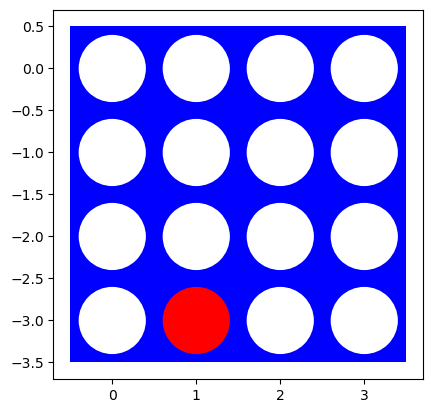

```
Number of nodes searched: 13711
Agent chose column: 1, with value: 4
Updated board:
```

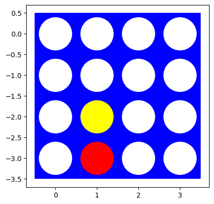

```
Number of nodes searched: 11145
Agent chose column: 1, with value: 0
Updated board:
```

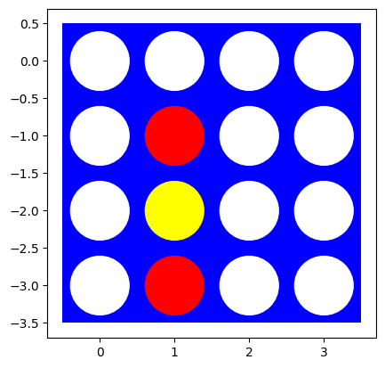

```
Number of nodes searched: 3095
Agent chose column: 1, with value: 4
Updated board:
```

[figure not shown]

```
Number of nodes searched: 1811
Agent chose column: 2, with value: 0
Updated board:
```

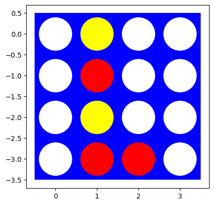

```
Number of nodes searched: 770
Agent chose column: 3, with value: 4
Updated board:
```

[figure not shown]

```
Number of nodes searched: 571
Agent chose column: 0, with value: 0
Updated board:
```

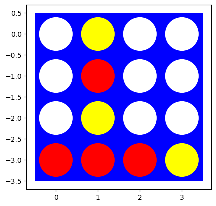

```
Number of nodes searched: 224
Agent chose column: 2, with value: 0
Updated board:
```

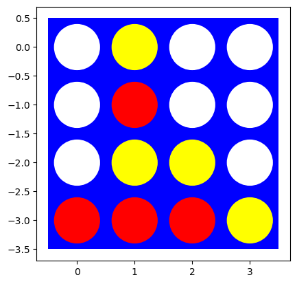

```
Number of nodes searched: 154
Agent chose column: 2, with value: 0
Updated board:
```

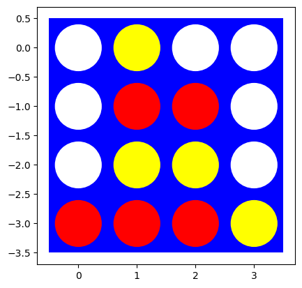

```
Number of nodes searched: 64
Agent chose column: 2, with value: 0
Updated board:
```

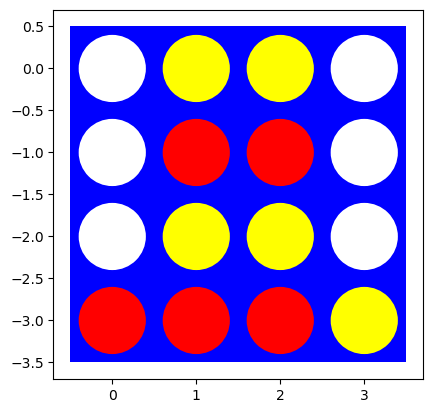

```
Number of nodes searched: 31
Agent chose column: 0, with value: 0
Updated board:
```

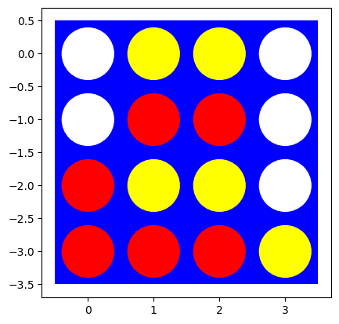

```
Number of nodes searched: 16
Agent chose column: 0, with value: 0
Updated board:
```

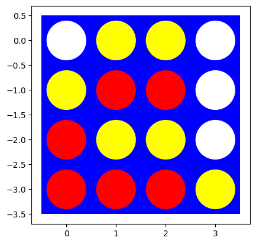

```
Number of nodes searched: 9
Agent chose column: 0, with value: 0
Updated board:
```

[5 more figures not shown]

```python
import math
import numpy as np

class Connect4Agent:
    def __init__(self):
        self.DEBUG = 1  # For debugging purposes
        self.COUNT = 0

    def alpha_beta_search(self, board, player=1):
        """Start the search."""
        self.COUNT = 0
        value, move = self.max_value_ab(board, player, -math.inf, +math.inf)

        if self.DEBUG >= 1:
            print(f"Number of nodes searched: {self.COUNT}")

        return {"move": move, "value": value}

    def max_value_ab(self, state, player, alpha, beta):
        """Player's best move."""
        self.COUNT += 1
        v = self.utility(state, player)
        if self.DEBUG >= 2:
            print(f"max: {state} [alpha,beta]=[{alpha},{beta}] v={v}")
        if v is not None:
            if self.DEBUG >= 2:
                print(f" found terminal state. backtracking.")
            return v, None

        v, move = -math.inf, None

        for a in self.actions(state):
            v2, _ = self.min_value_ab(self.result(state, player, a), player, alpha, beta)
            if self.DEBUG >= 2:
                print(f"max: {state} (backtracked) [alpha,beta]=[{alpha},{beta}] v={v2}")

            if v2 > v:
                v, move = v2, a
            alpha = max(alpha, v)
            if v >= beta:
                if self.DEBUG >= 2:
                    print(f" v >= beta ({v} >= {beta}): pruning remaining subtree.")
                return v, move

        return v, move

    def min_value_ab(self, state, player, alpha, beta):
        """Opponent's best response."""
        self.COUNT += 1
        v = self.utility(state, player)
        if self.DEBUG >= 2:
            print(f"min: {state} [alpha,beta]=[{alpha},{beta}] v={v}")
        if v is not None:
            if self.DEBUG >= 2:
                print(f" found terminal state. backtracking.")
            return v, None

        v, move = +math.inf, None

        for a in self.actions(state):
            v2, _ = self.max_value_ab(self.result(state, self.other(player), a), player, alpha, beta)
            if self.DEBUG >= 2:
                print(f"min: {state} (backtracked) [alpha,beta]=[{alpha},{beta}] v={v2}")

            if v2 < v:
                v, move = v2, a
            beta = min(beta, v)
            if v <= alpha:
                if self.DEBUG >= 2:
                    print(f" v <= alpha ({v} <= {alpha}): pruning remaining subtree.")
                return v, move

        return v, move

    def utility(self, state, player):
        """Evaluate the board state."""
        if self.is_winner(state, player):
            return 4  # Player wins
        elif self.is_winner(state, self.other(player)):
            return -4  # Opponent wins
        elif self.is_full(state):
            return 0  # Draw
        return None  # Game continues

    def evaluate_move(self, state, player, column):
        """Evaluate the potential of a move in a given column."""
        # Check if the move results in a win for the player
        if self.is_winner(self.result(state, player, column), player):
            return 1000  # High score for a winning move

        # Check if the move blocks the opponent's winning move
        opponent = self.other(player)
        if self.is_winner(self.result(state, opponent, column), opponent):
            return 900  # High score for blocking the opponent's winning move

        # Score based on column preference (higher for central columns)
        central_column_score = 0
        if column == 1 or column == 2:  # Central columns
            central_column_score = 5

        return central_column_score  # Return the score based on column preference

    def actions(self, state):
        """Return a sorted list of valid actions (columns to drop a piece)."""
        valid_moves = []

        for col in range(4):  # Assuming a 4-column grid (adjust if necessary)
            if state[0][col] == 0:  # Check if the column is not full
                score = self.evaluate_move(state, 1, col)  # Evaluate the move
                valid_moves.append((col, score))

        # Sort moves based on the evaluated score in descending order
        valid_moves.sort(key=lambda x: x[1], reverse=True)

        # Return only the columns sorted by heuristic value
        return [col for col, _ in valid_moves]

    def result(self, state, player, action):
        """Return the resulting state after applying the action."""
        new_state = state.copy()
        for row in range(3, -1, -1):  # Find the first available row in the column
            if new_state[row][action] == 0:
                new_state[row][action] = 1 if player == 1 else -1
                break
        return new_state

    def is_winner(self, state, player):
        """Check if the player has won the game."""
        for row in range(4):
            for col in range(4):
                if state[row][col] == (1 if player == 1 else -1):
                    # Check horizontal
                    if col + 3 < 4 and all(state[row][col + i] == state[row][col] for i in range(4)):
                        return True
                    # Check vertical
                    if row + 3 < 4 and all(state[row + i][col] == state[row][col] for i in range(4)):
                        return True
                    # Check diagonal /
                    if row + 3 < 4 and col + 3 < 4 and all(state[row + i][col + i] == state[row][col] for i in range(4)):
                        return True
                    # Check diagonal \
                    if row - 3 >= 0 and col + 3 < 4 and all(state[row - i][col + i] == state[row][col] for i in range(4)):
                        return True
        return False

    def is_full(self, state):
        """Check if the board is full (draw condition)."""
        return all(state[0][col] != 0 for col in range(4))

    def other(self, player):
        """Return the opponent's player."""
        return -1 if player == 1 else 1


# Example of using the agent with a predefined board

# Predefined game board (4x4) with some pieces
# 0 = empty, 1 = player 1, -1 = player -1
board = np.array([
    [0, 0, 0, 0],
    [0, 0, 0, 0],
    [0, 0, 0, 0],
    [0, 0, 0, 0]
])
player=1
# Initialize the agent (for player 1)
while True:
    agent = Connect4Agent()

    # Run the agent's alpha-beta search to get the next move for player 1
    move_info = agent.alpha_beta_search(board, player=1)

    # Print the chosen move and board value
    print(f"Agent chose column: {move_info['move']}, with value: {move_info['value']}")

    # Update the board with the chosen move
    if move_info['move'] is not None:
        board = agent.result(board, player, move_info['move'])

    # Print the updated board
    print("Updated board:")
    visualize(board)
    player=agent.other(player)
    if agent.utility(board,player)==4 or agent.utility(board,player)==-4 or move_info['move']==None:
        break
```